# PIA - TIA - Avance Descriptivo - Versión 1

Estadística Aplicada a Seguridad en TI

- Diego Francisco Martinez Reyes - [2118638]

- Victor Adrian Rodriguez Ortiz - [1909518]

- Ana Laura Palacios Salazar - [2115510]

08 de noviembre de 2026

# 1. Preparación y Auditoría de Datos

## 1.1 Entorno, Dependencias y Carga Reproducible

Para garantizar la reproducibilidad del entorno, configuramos las dependencias sin usar rutas absolutas.

```r
library(tidyverse)
library(knitr)
```

- **Versión de R utilizada:** R version 4.6.2 (2026-10-29 ucrt)
- **Versión de `tidyverse`:** 2.0.0
- **Versión de `knitr`:** 1.52

Se carga el conjunto de datos `PhiUSIIL_Phishing_URL_Dataset.csv` directamente desde el directorio de trabajo o la carpeta de datos.

```r
ruta_archivo <- "PhiUSIIL_Phishing_URL_Dataset.csv"

# Búsqueda de archivo en directorio raíz o carpeta 'data'
if (!file.exists(ruta_archivo)) {
  ruta_archivo <- file.path("data", "PhiUSIIL_Phishing_URL_Dataset.csv")
}

datos_brutos <- read.csv(ruta_archivo, stringsAsFactors = FALSE)
```

## 1.2 Verificación de Estructura y Recodificación de Clase

En el archivo original, la variable objetivo `label` codifica con `1` a los sitios legítimos y con `0` a los sitios de phishing. Para evaluar correctamente el desempeño de nuestro sistema (donde el evento a detectar es el ataque), recodificaremos la clase positiva como **Amenaza/Phishing = 1** y **Legítimo = 0**.

```r
# 1. Dimensiones iniciales, valores faltantes y duplicados
n_obs_inicial <- nrow(datos_brutos)
n_cols_inicial <- ncol(datos_brutos)
total_faltantes <- sum(is.na(datos_brutos))
duplicados_exactos <- sum(duplicated(datos_brutos))
duplicados_url <- sum(duplicated(datos_brutos$URL))

# 2. Limpieza de duplicados por unidad de análisis (URL) y recodificación
# Se eliminan las URLs duplicadas para impedir fuga de información entre particiones
datos_unicos <- datos_brutos %>%
  distinct(URL, .keep_all = TRUE) %>%
  mutate(
    # Recodificación: Clase positiva de interés (Amenaza/Phishing) = 1, Legítimo = 0
    phishing_num = ifelse(label == 0, 1L, 0L),
    clase = factor(
      ifelse(label == 0, "Phishing", "Legitimo"),
      levels = c("Legitimo", "Phishing")
    )
  )

n_obs_limpio <- nrow(datos_unicos)

# Tabla resumen de estructura y calidad
tabla_calidad <- tibble(
  Indicador = c(
    "Observaciones brutas en el archivo CSV",
    "Variables totales en el archivo original",
    "Total de valores faltantes (NA)",
    "Filas idénticas duplicadas (incluyendo FILENAME)",
    "URLs duplicadas detectadas y removidas",
    "Observaciones únicas finales (unidades de análisis)",
    "Sitios Legítimos (clase = 0 tras recodificar)",
    "Sitios de Phishing / Amenaza (clase = 1 tras recodificar)"
  ),
  Valor = c(
    format(n_obs_inicial, big.mark = ","),
    as.character(n_cols_inicial),
    as.character(total_faltantes),
    as.character(duplicados_exactos),
    as.character(duplicados_url),
    format(n_obs_limpio, big.mark = ","),
    paste0(format(sum(datos_unicos$phishing_num == 0), big.mark = ","),
           " (", round(mean(datos_unicos$phishing_num == 0) * 100, 2), "%)"),
    paste0(format(sum(datos_unicos$phishing_num == 1), big.mark = ","),
           " (", round(mean(datos_unicos$phishing_num == 1) * 100, 2), "%)")
  )
)

kable(
  tabla_calidad,
  caption = "Tabla 1. Resumen de dimensiones, limpieza y distribución de clases."
)
```

Tabla 1. Resumen de dimensiones, limpieza y distribución de clases.

| Indicador | Valor |
| --- | --- |
| Observaciones brutas en el archivo CSV | 235,795 |
| Variables totales en el archivo original | 56 |
| Total de valores faltantes (NA) | 0 |
| Filas idénticas duplicadas (incluyendo FILENAME) | 0 |
| URLs duplicadas detectadas y removidas | 425 |
| Observaciones únicas finales (unidades de análisis) | 235,370 |
| Sitios Legítimos (clase = 0 tras recodificar) | 134,850 (57.29%) |
| Sitios de Phishing / Amenaza (clase = 1 tras recodificar) | 100,520 (42.71%) |

## 1.3 Tipología de Variables y Fuga de Información (*Data Leakage*)

En esta sección identificamos el tipo de variables predictoras y evaluamos un riesgo importante: la separación cuasi-completa. Si una variable tiene varianza cero dentro de una de las clases, su inclusión directa en algoritmos de aprendizaje o regresiones puede provocar predicciones artificiales sesgadas.

```r
# Identificación de tipos de variables predictoras
vars_texto_id <- c("FILENAME", "URL", "Domain", "TLD", "Title")
vars_predictoras_num <- setdiff(
  names(datos_brutos),
  c(vars_texto_id, "label")
)

es_binaria <- sapply(datos_unicos[vars_predictoras_num], function(x) {
  all(unique(x) %in% c(0, 1))
})

vars_binarias <- vars_predictoras_num[es_binaria]
vars_cuantitativas <- vars_predictoras_num[!es_binaria]

# Tabla de clasificación funcional de variables (Requisito Sección 3.1)
resumen_tipos <- tibble(
  Categoria = c(
    "Identificadoras y texto libre (excluidas de modelación)",
    "Predictoras binarias / indicadoras (0 o 1)",
    "Predictoras cuantitativas (conteos, longitudes y tasas)",
    "Variable de respuesta recodificada"
  ),
  Cantidad = c(
    length(vars_texto_id),
    length(vars_binarias),
    length(vars_cuantitativas),
    1
  ),
  Ejemplos = c(
    paste(vars_texto_id, collapse = ", "),
    paste(head(vars_binarias, 5), collapse = ", "),
    paste(head(vars_cuantitativas, 5), collapse = ", "),
    "phishing_num (1 = Phishing, 0 = Legítimo) / factor clase"
  )
)

kable(
  resumen_tipos,
  caption = "Tabla 2. Clasificación funcional de las 56 variables del dataset."
)
```

Tabla 2. Clasificación funcional de las 56 variables del dataset.

| Categoria | Cantidad | Ejemplos |
| --- | --- | --- |
| Identificadoras y texto libre (excluidas de modelación) | 5 | FILENAME, URL, Domain, TLD, Title |
| Predictoras binarias / indicadoras (0 o 1) | 19 | IsDomainIP, HasObfuscation, IsHTTPS, HasTitle, HasFavicon |
| Predictoras cuantitativas (conteos, longitudes y tasas) | 31 | URLLength, DomainLength, URLSimilarityIndex, CharContinuationRate, TLDLegitimateProb |
| Variable de respuesta recodificada | 1 | phishing_num (1 = Phishing, 0 = Legítimo) / factor clase |

```r
# Auditoría de variables con varianza cero
auditoria_separabilidad <- datos_unicos %>%
  select(all_of(vars_predictoras_num), clase) %>%
  pivot_longer(cols = -clase, names_to = "Variable", values_to = "Valor") %>%
  group_by(Variable, clase) %>%
  summarise(
    Media = mean(Valor),
    DE = sd(Valor),
    Min = min(Valor),
    Max = max(Valor),
    .groups = "drop"
  ) %>%
  pivot_wider(
    names_from = clase,
    values_from = c(Media, DE, Min, Max)
  ) %>%
  filter(DE_Legitimo == 0 | DE_Phishing == 0) %>%
  select(
    Variable,
    Media_Legitimo, DE_Legitimo,
    Media_Phishing, DE_Phishing
  )

kable(
  auditoria_separabilidad,
  digits = 4,
  caption = "Tabla 3. Variables con desviación estándar igual a cero en la clase Legítima (Alerta de separación perfecta)."
)
```

Tabla 3. Variables con desviación estándar igual a cero en la clase Legítima (Alerta de separación perfecta).

| Variable | Media_Legitimo | DE_Legitimo | Media_Phishing | DE_Phishing |
| --- | --- | --- | --- | --- |
| HasObfuscation | 0 | 0 | 0.0048 | 0.0692 |
| IsDomainIP | 0 | 0 | 0.0063 | 0.0793 |
| IsHTTPS | 1 | 0 | 0.4912 | 0.4999 |
| NoOfAmpersandInURL | 0 | 0 | 0.0587 | 1.2803 |
| NoOfEqualsInURL | 0 | 0 | 0.1459 | 1.4273 |
| NoOfObfuscatedChar | 0 | 0 | 0.0583 | 2.8733 |
| NoOfQMarkInURL | 0 | 0 | 0.0689 | 0.2916 |
| ObfuscationRatio | 0 | 0 | 0.0003 | 0.0058 |
| URLSimilarityIndex | 100 | 0 | 49.6515 | 22.5786 |

**Comentario sobre calidad y sesgo:** Destaca el caso de `URLSimilarityIndex`, donde el $100\%$ de los sitios legítimos presentan un valor constante de $100$. De igual forma, ciertas variables asociadas a la URL (ej. `IsHTTPS`, presencia de interrogaciones o ampersands) tienen varianza cero en los dominios legítimos. Esto va derivado de comparar sitios legítimos recolectados en su dominio raíz frente a sitios de phishing obtenidos con rutas profundas completas. Estas variables deberán ser excluidas o tratadas con cuidado en la etapa de modelación para evitar falsos positivos.

## 1.4 Dataset Final para Análisis

Retiramos las variables identificadoras (texto libre) y la etiqueta original para dejar un entorno de datos estructurado.

```r
# Se excluyen identificadores de texto libre y la etiqueta original 'label'
vars_varianza_cero_legit <- auditoria_separabilidad$Variable

datos_limpios <- datos_unicos %>%
  select(-FILENAME, -URL, -Domain, -Title, -label)

cat("El conjunto 'datos_limpios' queda estructurado con",
    nrow(datos_limpios), "observaciones y", ncol(datos_limpios), "columnas.\n")
```

```
## El conjunto 'datos_limpios' queda estructurado con 235370 observaciones y 53 columnas.
```

# 2. Análisis Univariado y Diccionario

*(Se usa el objeto `datos_limpios`, `vars_cuantitativas` y `vars_binarias`)*

## 2.1 Diccionario de Variables

```r
library(knitr)
library(dplyr)

# Verificar la existencia de datos_limpios
if (!exists("datos_limpios")) {
  stop("El objeto 'datos_limpios' no se encuentra cargado en el entorno.")
}

# Generación dinámica del diccionario sobre las 53 variables del dataset: datos_limpios
diccionario_53 <- data.frame(
  Variable = names(datos_limpios),
  Tipo_Dato_R = sapply(datos_limpios, class),
  stringsAsFactors = FALSE
) %>%
  mutate(
    Tipo_Dato = case_when(
      Variable %in% c("URL", "Domain", "TLD", "FILENAME", "Title") ~ "Texto",
      Variable %in% c("label", "clase") ~ "Categoría",
      Tipo_Dato_R %in% c("numeric") ~ "Número continuo",
      Tipo_Dato_R %in% c("integer") & grepl("Is|Has|Bank|Pay|Crypto", Variable) ~ "Booleano",
      Tipo_Dato_R %in% c("integer") ~ "Número entero",
      Tipo_Dato_R %in% c("factor", "logical") ~ "Booleano",
      TRUE ~ "Otro"
    ),
    Tipo_Estadistico = case_when(
      Tipo_Dato %in% c("Texto", "Categoría", "Booleano") ~ "Cualitativa Nominal",
      Tipo_Dato == "Número entero" ~ "Cuantitativa Discreta",
      Tipo_Dato == "Número continuo" ~ "Cuantitativa Continua",
      TRUE ~ "Cualitativa Nominal"
    ),
    Descripcion = case_when(
      # Meta e Identificadores
      Variable == "URL" ~ "Dirección URL completa analizada",
      Variable == "Domain" ~ "Nombre del dominio principal tomado de la URL",
      Variable == "TLD" ~ "Dominio de nivel superior",
      Variable %in% c("label", "clase") ~ "Variable de clasificación (0 = Legítimo, 1 = Phishing)",

      # Conteos y Longitudes (Discretas)
      Variable == "URLLength" ~ "Longitud total de caracteres de la URL",
      Variable == "DomainLength" ~ "Longitud de caracteres del nombre de dominio",
      Variable == "TLDLength" ~ "Longitud de la extensión TLD",
      Variable == "NoOfSubDomain" ~ "Cantidad de subdominios presentes en la URL",
      Variable == "NoOfLettersInURL" ~ "Cantidad de letras en la URL",
      Variable == "NoOfDegitsInURL" ~ "Cantidad de dígitos en la URL",
      Variable == "NoOfEqualsInURL" ~ "Conteo del carácter '=' en la URL",
      Variable == "NoOfQMarkInURL" ~ "Conteo del carácter '?' en la URL",
      Variable == "NoOfAmpersandInURL" ~ "Conteo del carácter '&' en la URL",
      Variable == "NoOfOtherSpecialCharsInURL" ~ "Cantidad de otros caracteres especiales en la URL",
      Variable == "NoOfObfuscatedChar" ~ "Cantidad de caracteres con codificación u ofuscación",
      Variable == "LineOfCode" ~ "Cantidad de líneas de código fuente HTML",
      Variable == "LargestLineLength" ~ "Longitud de caracteres de la línea HTML más larga",
      Variable == "NoOfURLRedirect" ~ "Número de redirecciones de la URL",
      Variable == "NoOfSelfRedirect" ~ "Número de redirecciones dentro del mismo dominio",
      Variable == "NoOfPopup" ~ "Cantidad de ventanas emergentes (pop-ups) detectadas",
      Variable == "NoOfiFrame" ~ "Cantidad de marcos iFrame incrustados",
      Variable == "NoOfImage" ~ "Número de imágenes presentes en el documento HTML",
      Variable == "NoOfCSS" ~ "Número de archivos de hojas de estilo CSS enlazados",
      Variable == "NoOfJS" ~ "Número de archivos de código JavaScript enlazados",
      Variable == "NoOfSelfRef" ~ "Conteo de secciones/recursos con autorreferencia",
      Variable == "NoOfEmptyRef" ~ "Conteo de referencias o enlaces vacíos (href='#')",
      Variable == "NoOfExternalRef" ~ "Conteo de enlaces apuntando a dominios externos",

      # Probabilidades y Ratios (Continuas)
      Variable == "URLSimilarityIndex" ~ "Índice sintáctico de similitud con dominios legítimos",
      Variable == "CharContinuationRate" ~ "Tasa de continuidad de caracteres consecutivos",
      Variable == "TLDLegitimateProb" ~ "Probabilidad del TLD según legitimidad histórica",
      Variable == "URLCharProb" ~ "Probabilidad de distribución de caracteres en la URL",
      Variable == "ObfuscationRatio" ~ "Proporción de caracteres ofuscados respecto al total",
      Variable == "LetterRatioInURL" ~ "Proporción de letras respecto a la longitud de la URL",
      Variable == "DegitRatioInURL" ~ "Proporción de números respecto a la longitud de la URL",
      Variable == "EqualsRatioInURL" ~ "Proporción del carácter '=' en la URL",
      Variable == "QMarkRatioInURL" ~ "Proporción del carácter '?' en la URL",
      Variable == "AmpersandRatioInURL" ~ "Proporción del carácter '&' en la URL",
      Variable == "SpacialCharRatioInURL" ~ "Proporción de caracteres especiales en la URL",
      Variable == "TLDLengthRatio" ~ "Proporción entre la longitud del TLD y el dominio",
      Variable == "DomainTitleMatchScore" ~ "Puntaje de coincidencia entre dominio y título HTML",
      Variable == "URLTitleMatchScore" ~ "Puntaje de coincidencia entre URL completa y título HTML",

      # Banderas Binarias (Booleanas)
      Variable == "IsDomainIP" ~ "Indicador si el dominio es una IP (1) o no (0)",
      Variable == "IsHTTPS" ~ "Indicador de uso de protocolo seguro HTTPS (1) o no (0)",
      Variable == "HasObfuscation" ~ "Presencia de técnicas de ofuscación (1) o no (0)",
      Variable == "HasTitle" ~ "Presencia de etiqueta de título HTML",
      Variable == "HasFavicon" ~ "Presencia de icono Favicon en la página",
      Variable == "IsResponsive" ~ "Indicador de formato web responsivo",
      Variable == "HasDescription" ~ "Presencia de etiqueta meta de descripción",
      Variable == "HasExternalFormSubmit" ~ "Formulario que envía datos a dominio externo",
      Variable == "HasSocialNet" ~ "Presencia de enlaces a redes sociales",
      Variable == "HasSubmitButton" ~ "Presencia de botón de envío en formularios",
      Variable == "HasHiddenFields" ~ "Presencia de campos ocultos en formularios",
      Variable == "HasPasswordField" ~ "Presencia de campo para entrada de contraseña",
      Variable == "Bank" ~ "Indicador de referencias/palabras clave bancarias",
      Variable == "Pay" ~ "Indicador de palabras clave de plataformas de pago",
      Variable == "Crypto" ~ "Indicador de referencias a criptomonedas o billeteras",

      TRUE ~ "Métrica de análisis estructurado del sitio web"
    )
  )

# Despliegue formal del diccionario para las 53 variables reales
knitr::kable(
  diccionario_53 %>% select(Variable, Tipo_Dato, Tipo_Estadistico, Descripcion),
  col.names = c("Variable", "Tipo de Dato", "Tipo Estadístico", "Descripción"),
  row.names = FALSE,
  caption = "Tabla 4. Diccionario completo de las 53 variables resultantes del dataset: datos_limpios"
)
```

Tabla 4. Diccionario completo de las 53 variables resultantes del dataset: datos_limpios

| Variable | Tipo de Dato | Tipo Estadístico | Descripción |
| --- | --- | --- | --- |
| URLLength | Número entero | Cuantitativa Discreta | Longitud total de caracteres de la URL |
| DomainLength | Número entero | Cuantitativa Discreta | Longitud de caracteres del nombre de dominio |
| IsDomainIP | Booleano | Cualitativa Nominal | Indicador si el dominio es una IP (1) o no (0) |
| TLD | Texto | Cualitativa Nominal | Dominio de nivel superior |
| URLSimilarityIndex | Número continuo | Cuantitativa Continua | Índice sintáctico de similitud con dominios legítimos |
| CharContinuationRate | Número continuo | Cuantitativa Continua | Tasa de continuidad de caracteres consecutivos |
| TLDLegitimateProb | Número continuo | Cuantitativa Continua | Probabilidad del TLD según legitimidad histórica |
| URLCharProb | Número continuo | Cuantitativa Continua | Probabilidad de distribución de caracteres en la URL |
| TLDLength | Número entero | Cuantitativa Discreta | Longitud de la extensión TLD |
| NoOfSubDomain | Número entero | Cuantitativa Discreta | Cantidad de subdominios presentes en la URL |
| HasObfuscation | Booleano | Cualitativa Nominal | Presencia de técnicas de ofuscación (1) o no (0) |
| NoOfObfuscatedChar | Número entero | Cuantitativa Discreta | Cantidad de caracteres con codificación u ofuscación |
| ObfuscationRatio | Número continuo | Cuantitativa Continua | Proporción de caracteres ofuscados respecto al total |
| NoOfLettersInURL | Número entero | Cuantitativa Discreta | Cantidad de letras en la URL |
| LetterRatioInURL | Número continuo | Cuantitativa Continua | Proporción de letras respecto a la longitud de la URL |
| NoOfDegitsInURL | Número entero | Cuantitativa Discreta | Cantidad de dígitos en la URL |
| DegitRatioInURL | Número continuo | Cuantitativa Continua | Proporción de números respecto a la longitud de la URL |
| NoOfEqualsInURL | Número entero | Cuantitativa Discreta | Conteo del carácter ‘=’ en la URL |
| NoOfQMarkInURL | Número entero | Cuantitativa Discreta | Conteo del carácter ‘?’ en la URL |
| NoOfAmpersandInURL | Número entero | Cuantitativa Discreta | Conteo del carácter ‘&’ en la URL |
| NoOfOtherSpecialCharsInURL | Número entero | Cuantitativa Discreta | Cantidad de otros caracteres especiales en la URL |
| SpacialCharRatioInURL | Número continuo | Cuantitativa Continua | Proporción de caracteres especiales en la URL |
| IsHTTPS | Booleano | Cualitativa Nominal | Indicador de uso de protocolo seguro HTTPS (1) o no (0) |
| LineOfCode | Número entero | Cuantitativa Discreta | Cantidad de líneas de código fuente HTML |
| LargestLineLength | Número entero | Cuantitativa Discreta | Longitud de caracteres de la línea HTML más larga |
| HasTitle | Booleano | Cualitativa Nominal | Presencia de etiqueta de título HTML |
| DomainTitleMatchScore | Número continuo | Cuantitativa Continua | Puntaje de coincidencia entre dominio y título HTML |
| URLTitleMatchScore | Número continuo | Cuantitativa Continua | Puntaje de coincidencia entre URL completa y título HTML |
| HasFavicon | Booleano | Cualitativa Nominal | Presencia de icono Favicon en la página |
| Robots | Número entero | Cuantitativa Discreta | Métrica de análisis estructurado del sitio web |
| IsResponsive | Booleano | Cualitativa Nominal | Indicador de formato web responsivo |
| NoOfURLRedirect | Número entero | Cuantitativa Discreta | Número de redirecciones de la URL |
| NoOfSelfRedirect | Número entero | Cuantitativa Discreta | Número de redirecciones dentro del mismo dominio |
| HasDescription | Booleano | Cualitativa Nominal | Presencia de etiqueta meta de descripción |
| NoOfPopup | Número entero | Cuantitativa Discreta | Cantidad de ventanas emergentes (pop-ups) detectadas |
| NoOfiFrame | Número entero | Cuantitativa Discreta | Cantidad de marcos iFrame incrustados |
| HasExternalFormSubmit | Booleano | Cualitativa Nominal | Formulario que envía datos a dominio externo |
| HasSocialNet | Booleano | Cualitativa Nominal | Presencia de enlaces a redes sociales |
| HasSubmitButton | Booleano | Cualitativa Nominal | Presencia de botón de envío en formularios |
| HasHiddenFields | Booleano | Cualitativa Nominal | Presencia de campos ocultos en formularios |
| HasPasswordField | Booleano | Cualitativa Nominal | Presencia de campo para entrada de contraseña |
| Bank | Booleano | Cualitativa Nominal | Indicador de referencias/palabras clave bancarias |
| Pay | Booleano | Cualitativa Nominal | Indicador de palabras clave de plataformas de pago |
| Crypto | Booleano | Cualitativa Nominal | Indicador de referencias a criptomonedas o billeteras |
| HasCopyrightInfo | Booleano | Cualitativa Nominal | Métrica de análisis estructurado del sitio web |
| NoOfImage | Número entero | Cuantitativa Discreta | Número de imágenes presentes en el documento HTML |
| NoOfCSS | Número entero | Cuantitativa Discreta | Número de archivos de hojas de estilo CSS enlazados |
| NoOfJS | Número entero | Cuantitativa Discreta | Número de archivos de código JavaScript enlazados |
| NoOfSelfRef | Número entero | Cuantitativa Discreta | Conteo de secciones/recursos con autorreferencia |
| NoOfEmptyRef | Número entero | Cuantitativa Discreta | Conteo de referencias o enlaces vacíos (href=‘#’) |
| NoOfExternalRef | Número entero | Cuantitativa Discreta | Conteo de enlaces apuntando a dominios externos |
| phishing_num | Número entero | Cuantitativa Discreta | Métrica de análisis estructurado del sitio web |
| clase | Categoría | Cualitativa Nominal | Variable de clasificación (0 = Legítimo, 1 = Phishing) |

```r
# la tabla 1 se renombró a tabla 4
```

## 2.2 Medidas de Centro y Dispersión

```r
library(knitr)
library(dplyr)

# Función para calcular medidas de centro, dispersión y cuantiles sobre datos_limpios
calcular_medidas <- function(df, variable) {
  x <- df[[variable]]
  x <- x[!is.na(x)] # Remover valores NAs

  data.frame(
    Variable           = variable,
    Media              = round(mean(x), 4),
    Mediana            = round(median(x), 4),
    Desv_Estandar      = round(sd(x), 4),
    Varianza           = round(var(x), 4),
    Rango_Intercuartil = round(IQR(x), 4),
    Rango_Total        = round(diff(range(x)), 4),
    Q1_p25             = round(quantile(x, 0.25), 4),
    Q2_p50             = round(quantile(x, 0.50), 4),
    Q3_p75             = round(quantile(x, 0.75), 4),
    Percentil_90       = round(quantile(x, 0.90), 4)
  )
}

# Selección de las variables numéricas más representativas presentes en vars_cuantitativas
vars_analisis <- intersect(
  c("URLSimilarityIndex", "URLLength", "CharContinuationRate", "TLDLegitimateProb", "URLCharProb", "NoOfObfuscatedChar"),
  vars_cuantitativas
)

# Generar tabla consolidada sobre datos_limpios
tabla_medidas_resumen <- do.call(rbind, lapply(vars_analisis, function(v) calcular_medidas(datos_limpios, v)))

# Renderizado de la Tabla 5 (antes 2)
kable(
  tabla_medidas_resumen,
  col.names = c("Variable", "Media", "Mediana", "Desviación Estándar", "Varianza", "IQR", "Rango", "Q1 (p25)", "Q2 (p50)", "Q3 (p75)", "P90"),
  row.names = FALSE,
  caption = "Tabla 5. Medidas de tendencia central, dispersión y cuantiles sobre el dataset datos_limpios"
)
```

Tabla 5. Medidas de tendencia central, dispersión y cuantiles sobre el dataset datos_limpios

| Variable | Media | Mediana | Desviación Estándar | Varianza | IQR | Rango | Q1 (p25) | Q2 (p50) | Q3 (p75) | P90 |
| --- | --- | --- | --- | --- | --- | --- | --- | --- | --- | --- |
| URLSimilarityIndex | 78.4975 | 100.000 | 28.9479 | 837.9808 | 42.8333 | 99.8444 | 57.1667 | 100.000 | 100.0000 | 100.0000 |
| URLLength | 34.5455 | 27.000 | 41.3327 | 1708.3946 | 11.0000 | 6084.0000 | 23.0000 | 27.000 | 34.0000 | 50.0000 |
| CharContinuationRate | 0.8459 | 1.000 | 0.2164 | 0.0468 | 0.3200 | 1.0000 | 0.6800 | 1.000 | 1.0000 | 1.0000 |
| TLDLegitimateProb | 0.2605 | 0.080 | 0.2516 | 0.0633 | 0.5169 | 0.5229 | 0.0060 | 0.080 | 0.5229 | 0.5229 |
| URLCharProb | 0.0558 | 0.058 | 0.0106 | 0.0001 | 0.0121 | 0.0897 | 0.0508 | 0.058 | 0.0629 | 0.0669 |
| NoOfObfuscatedChar | 0.0249 | 0.000 | 1.8779 | 3.5266 | 0.0000 | 447.0000 | 0.0000 | 0.000 | 0.0000 | 0.0000 |

## 2.3 Visualizaciones Univariadas y Distribución de Clases

Para entender la estructura y comportamiento de los datos, se diseñaron tres gráficas univariadas enfocadas en la similitud de URLs legitimas y maliciosas, la longitud de las URL y la proporción entre los tipos de sitio analizados.

### Figura 1. Distribución de Similitud de URL

**Descripción de la gráfica:** Esta visualización combina un histograma con una curva de densidad para mostrar cómo se distribuyen los valores del índice de similitud (`URLSimilarityIndex`) en las URLs evaluadas. Permite identificar si los datos se concentran en un rango específico o si se reparten a lo largo de toda la gráfica.

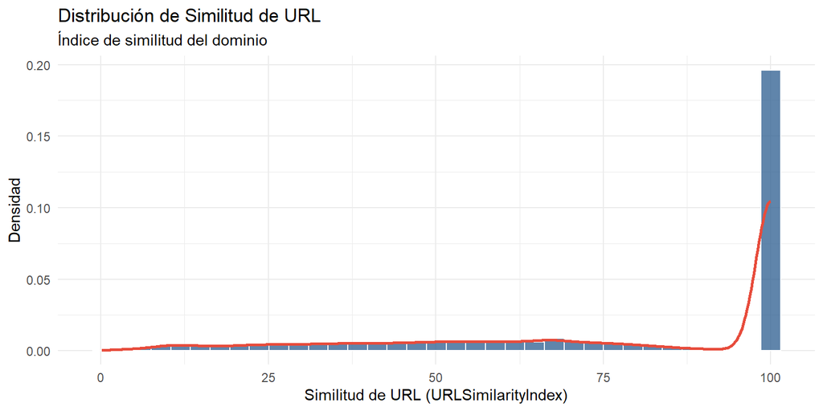

```r
library(ggplot2)

ggplot(datos_limpios, aes(x = URLSimilarityIndex)) +
  geom_histogram(aes(y = ..density..), bins = 35, fill = "#2b5c8f", color = "white", alpha = 0.75) +
  geom_density(color = "#e74c3c", size = 1) +
  labs(
    title = "Distribución de Similitud de URL",
    subtitle = "Índice de similitud del dominio",
    x = "Similitud de URL (URLSimilarityIndex)",
    y = "Densidad"
  ) +
  theme_minimal()
```

**Explicación:** La gran mayoría de los registros se concentran cerca del valor 100, lo que indica que una proporción alta de los dominios en la muestra tienen un formato que imita o coincide con dominios web legítimos. Por otro lado, la línea roja que baja hacia la izquierda muestra que existe pocos sitios con índices de similitud bajos, que es la franja donde suelen ubicarse algunas variaciones de phishing.

### Figura 2. Longitud de las URLs

**Descripción de la gráfica:** Es un diagrama de caja (*boxplot*) graficado en escala logarítmica que evalúa la variable `URLLength`. Representa visualmente el punto central de los datos (la mediana), la extensión de la mitad de los registros (rango intercuartílico) y la presencia de valores que están fuera de lo común.

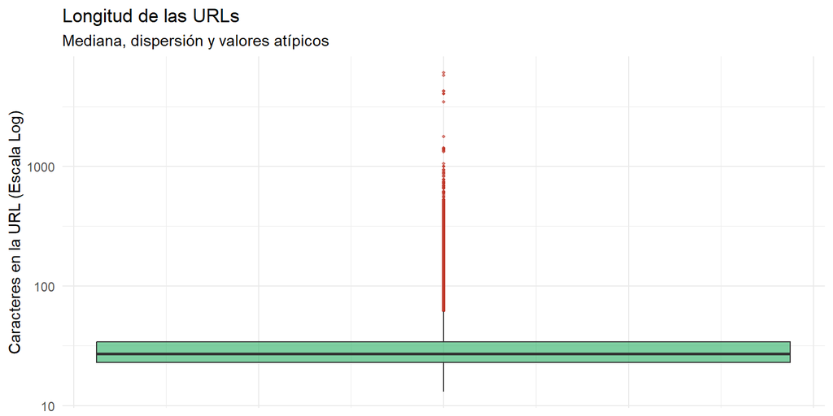

```r
ggplot(datos_limpios, aes(y = URLLength)) +
  geom_boxplot(fill = "#27ae60", alpha = 0.6, outlier.color = "#c0392b", outlier.size = 0.8) +
  scale_y_log10() +
  labs(
    title = "Longitud de las URLs",
    subtitle = "Mediana, dispersión y valores atípicos",
    y = "Caracteres en la URL (Escala Log)"
  ) +
  theme_minimal() +
  theme(axis.text.x = element_blank())
```

**Explicación:** El rectangulo verde de la parte inferior demuestra que la mayoría de las URLs analizadas tienen una longitud estándar. Sin embargo, la acumulación de puntos rojos hacia arriba evidencia una gran cantidad de valores atípicos. En ciberseguridad, estas URLs con longitudes muy altas suelen significar enlaces maliciosos diseñados para esconder la verdadera dirección destino mediante múltiples parámetros y subdominios pegados.

### Figura 3. Cantidad de Sitios por Tipo

**Descripción de la gráfica:** Es un gráfico de barras que cuenta los registros de la variable respuesta (`clase` o `label`), mostrando tanto la cantidad total de URLs como el porcentaje que representa cada categoría dentro de la base de datos.

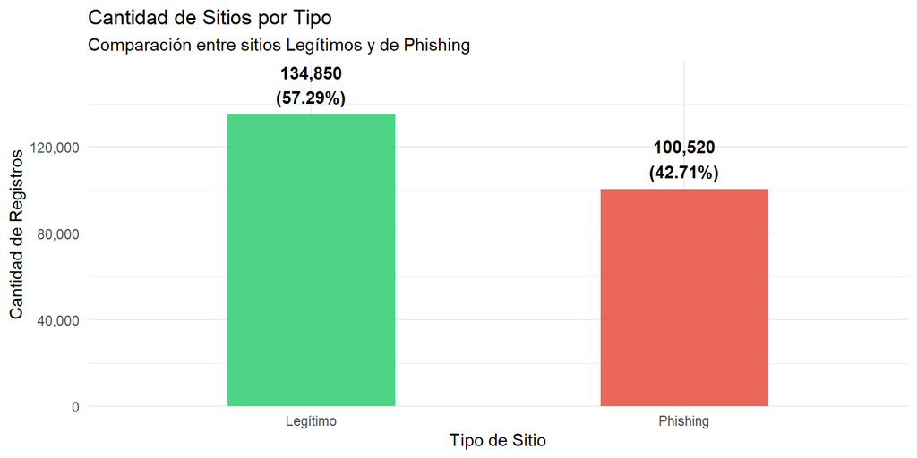

```r
library(dplyr)
library(scales)

var_objetivo <- if("clase" %in% names(datos_limpios)) "clase" else "label"

df_clases <- datos_limpios %>%
  count(.data[[var_objetivo]]) %>%
  rename(Target = 1) %>%
  mutate(
    Clase = if_else(as.character(Target) %in% c("1", "Phishing"), "Phishing", "Legítimo"),
    Proporcion = n / sum(n),
    Porcentaje = paste0(round(Proporcion * 100, 2), "%")
  )

ggplot(df_clases, aes(x = Clase, y = n, fill = Clase)) +
  geom_bar(stat = "identity", alpha = 0.85, width = 0.45) +
  geom_text(aes(label = paste0(format(n, big.mark = ","), "\n(", Porcentaje, ")")),
            vjust = -0.3, fontface = "bold", size = 3.8) +
  scale_fill_manual(values = c("Legítimo" = "#2ecc71", "Phishing" = "#e74c3c")) +
  scale_y_continuous(labels = comma, expand = expansion(mult = c(0, 0.18))) +
  labs(
    title = "Cantidad de Sitios por Tipo",
    subtitle = "Comparación entre sitios Legítimos y de Phishing",
    x = "Tipo de Sitio",
    y = "Cantidad de Registros"
  ) +
  theme_minimal() +
  theme(legend.position = "none")
```

**Explicación:** De las 235,370 observaciones totales en el dataset limpio, 134,850 registros corresponden a páginas **Legítimas** (57.29%) y 100,520 corresponden a sitios de **Phishing** (42.71%). Al mantener una proporción relativamente balanceada entre ambas clases, los datos quedan listos para análisis posteriores.

# 3. Análisis Bivariado y Correlaciones

*(Predictores contra la variable objetivo `clase`)*

## 3.1 Visualizaciones Comparativas

Para analizar cómo discriminan las variables predictoras entre sitios **Legítimos** y de **Phishing**, se comparan tanto variables cuantitativas (tasas y estructura del código HTML) como variables indicadoras binarias.

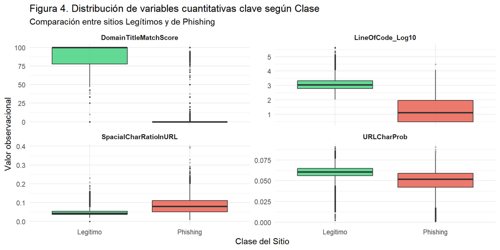

```r
# Figura 4: Comparación de predictoras cuantitativas por clase (Boxplots)
datos_biv_num <- datos_limpios %>%
  select(clase, SpacialCharRatioInURL, URLCharProb, LineOfCode, DomainTitleMatchScore) %>%
  mutate(LineOfCode_Log10 = log10(LineOfCode + 1)) %>%
  select(-LineOfCode) %>%
  pivot_longer(cols = -clase, names_to = "Variable", values_to = "Valor")

ggplot(datos_biv_num, aes(x = clase, y = Valor, fill = clase)) +
  geom_boxplot(alpha = 0.75, outlier.size = 0.5, outlier.alpha = 0.3) +
  facet_wrap(~ Variable, scales = "free_y", ncol = 2) +
  scale_fill_manual(values = c("Legitimo" = "#2ecc71", "Phishing" = "#e74c3c")) +
  labs(
    title = "Figura 4. Distribución de variables cuantitativas clave según Clase",
    subtitle = "Comparación entre sitios Legítimos y de Phishing",
    x = "Clase del Sitio",
    y = "Valor observacional"
  ) +
  theme_minimal() +
  theme(legend.position = "none", strip.text = element_text(face = "bold"))
```

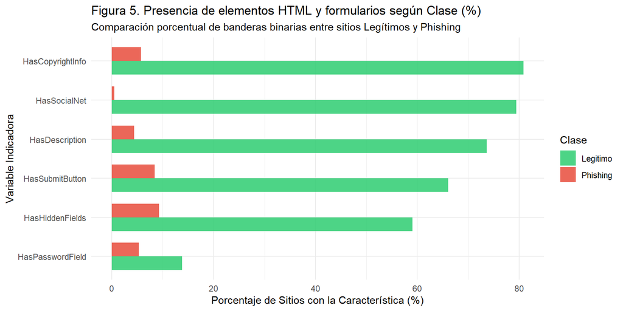

```r
# Figura 5: Proporción de características estructurales (binarias) por clase
datos_biv_bin <- datos_limpios %>%
  select(clase, HasSocialNet, HasCopyrightInfo, HasDescription, HasSubmitButton, HasHiddenFields, HasPasswordField) %>%
  pivot_longer(cols = -clase, names_to = "Caracteristica", values_to = "Presente") %>%
  group_by(clase, Caracteristica) %>%
  summarise(Porcentaje = mean(Presente) * 100, .groups = "drop")

ggplot(datos_biv_bin, aes(x = reorder(Caracteristica, Porcentaje), y = Porcentaje, fill = clase)) +
  geom_col(position = "dodge", alpha = 0.85, width = 0.7) +
  coord_flip() +
  scale_fill_manual(values = c("Legitimo" = "#2ecc71", "Phishing" = "#e74c3c")) +
  labs(
    title = "Figura 5. Presencia de elementos HTML y formularios según Clase (%)",
    subtitle = "Comparación porcentual de banderas binarias entre sitios Legítimos y Phishing",
    x = "Variable Indicadora",
    y = "Porcentaje de Sitios con la Característica (%)",
    fill = "Clase"
  ) +
  theme_minimal()
```

**Interpretación del análisis bivariado:** * **Proporción de caracteres especiales (`SpacialCharRatioInURL`):** Los sitios de *phishing* presentan una media ($0.0832$, mediana $0.0800$) casi del doble que los sitios legítimos ($0.0484$, mediana $0.0420$), debido al uso de guiones, símbolos y subrutas para simular dominios oficiales. * **Complejidad del código (`LineOfCode`):** Los sitios legítimos tienen una mediana de $1,105$ líneas de código HTML frente a apenas $12$ líneas en sitios de *phishing*, confirmando que las páginas maliciosas suelen ser plantillas ligeras de captura rápida. * **Indicadores estructurales (Figura 5):** Los sitios legítimos incluyen con mucha mayor frecuencia enlaces a redes sociales (`HasSocialNet`: $79.46\%$ vs. $0.51\%$), avisos de derechos de autor (`HasCopyrightInfo`: $80.82\%$ vs. $5.72\%$) y metadatos de descripción (`HasDescription`: $73.66\%$ vs. $4.41\%$).

## 3.2 Matriz de Correlaciones

Se calcula la matriz de correlación de Pearson entre las variables numéricas (excluyendo aquellas con varianza cero detectadas en la Sección 1.3) respecto a la variable objetivo recodificada `phishing_num` ($1 = \text{Phishing}, 0 = \text{Legítimo}$).

```r
# Seleccionar predictoras válidas (sin varianza cero) y calcular correlación con phishing_num
vars_validas_corr <- setdiff(
  names(datos_limpios),
  c("TLD", "clase", vars_varianza_cero_legit)
)

cor_con_objetivo <- cor(
  datos_limpios[, setdiff(vars_validas_corr, "phishing_num")],
  datos_limpios$phishing_num,
  use = "complete.obs"
)

# Extraer el Top 12 de variables con mayor correlación absoluta
top_12_vars <- head(rownames(cor_con_objetivo)[order(abs(cor_con_objetivo[, 1]), decreasing = TRUE)], 12)

tabla_top_corr <- tibble(
  Variable = top_12_vars,
  Correlacion_Pearson = round(cor_con_objetivo[top_12_vars, 1], 4),
  Relacion_con_Phishing = ifelse(
    cor_con_objetivo[top_12_vars, 1] > 0,
    "Positiva (Asociada a mayor presencia de Phishing)",
    "Negativa (Asociada a Sitios Legítimos)"
  )
)

kable(
  tabla_top_corr,
  col.names = c("Variable Predictora", "Correlación (r)", "Dirección del Efecto"),
  caption = "Tabla 6. Top 12 variables con mayor correlación absoluta respecto a Phishing (excluyendo variables con fuga de datos)."
)
```

Tabla 6. Top 12 variables con mayor correlación absoluta respecto a Phishing (excluyendo variables con fuga de datos).

| Variable Predictora | Correlación (r) | Dirección del Efecto |
| --- | --- | --- |
| HasSocialNet | -0.7839 | Negativa (Asociada a Sitios Legítimos) |
| HasCopyrightInfo | -0.7432 | Negativa (Asociada a Sitios Legítimos) |
| HasDescription | -0.6900 | Negativa (Asociada a Sitios Legítimos) |
| DomainTitleMatchScore | -0.5842 | Negativa (Asociada a Sitios Legítimos) |
| HasSubmitButton | -0.5788 | Negativa (Asociada a Sitios Legítimos) |
| IsResponsive | -0.5490 | Negativa (Asociada a Sitios Legítimos) |
| URLTitleMatchScore | -0.5388 | Negativa (Asociada a Sitios Legítimos) |
| SpacialCharRatioInURL | 0.5330 | Positiva (Asociada a mayor presencia de Phishing) |
| HasHiddenFields | -0.5077 | Negativa (Asociada a Sitios Legítimos) |
| HasFavicon | -0.4936 | Negativa (Asociada a Sitios Legítimos) |
| URLCharProb | -0.4695 | Negativa (Asociada a Sitios Legítimos) |
| CharContinuationRate | -0.4672 | Negativa (Asociada a Sitios Legítimos) |

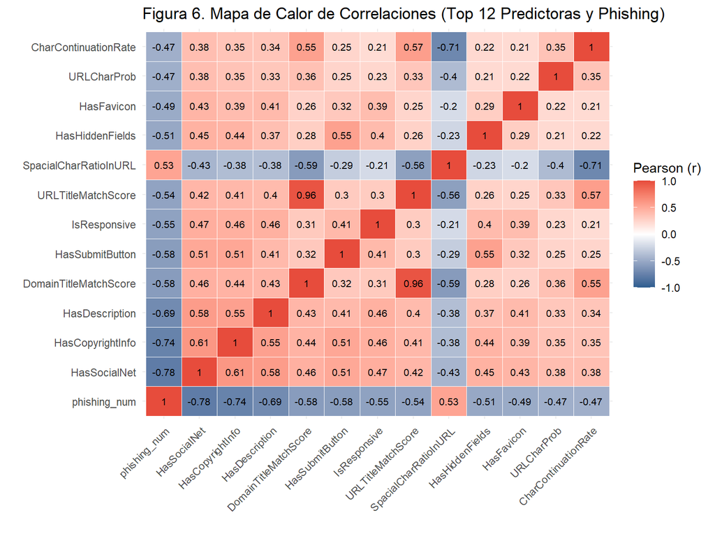

```r
# Mapa de calor (Heatmap) de la matriz de correlaciones del Top 12 + phishing_num
matriz_corr <- cor(datos_limpios[, c("phishing_num", top_12_vars)], use = "complete.obs")

matriz_larga <- as.data.frame(as.table(matriz_corr)) %>%
  rename(Var1 = 1, Var2 = 2, Correlacion = 3)

ggplot(matriz_larga, aes(x = Var1, y = Var2, fill = Correlacion)) +
  geom_tile(color = "white") +
  geom_text(aes(label = round(Correlacion, 2)), size = 2.8, color = "black") +
  scale_fill_gradient2(low = "#2b5c8f", mid = "white", high = "#e74c3c", midpoint = 0, limit = c(-1, 1)) +
  labs(
    title = "Figura 6. Mapa de Calor de Correlaciones (Top 12 Predictoras y Phishing)",
    x = "",
    y = "",
    fill = "Pearson (r)"
  ) +
  theme_minimal() +
  theme(axis.text.x = element_text(angle = 45, hjust = 1))
```